# 01_linear_regression

2024-09-01

## R Markdown

The dataset used this week is HIEDATA SHORT which is an excerpt from the RAND Health Insurance Experiment — a large, federally funded study conducted in the United States between 1971 and 1982. It contains data that are used to illustrate linear regression. For more details on using R Markdown see https://www.rand.org/health-care/projects/hie.html.

```r
# setwd("C:~/applied-regression-analysis")
load(file.path("data",'hiedata_short.Rdata'))
```

## Introdution to the task

To fit linear regression models for which the quantitative response variable is family income (i.e., income in the data frame hiedata_short). The variables education, age, and ghi (i.e., General Health Index) will be used as explanatory variables.

- `income`: A respondent’s family income recorded in thousands of 1973 dollars (i.e., income×1000 will give you the number of 1973 dollars).
- `education`: A respondent’s education in years of school completed.
- `age` : A respondent’s age in years.
- `ghi`: A respondent’s self-assessed general health based on a set of 22 survey questions. Each question was answered on a five-point scale, and the results were then summed across the 22 items. Higher scores represent better self-reported health

```r
# Look at the variable names in the data frame
# Variables/covariates are the columns
# Cases/respondents are the rows
colnames(hiedata_short)
```

```
##  [1] "person"        "age"           "education"     "income"
##  [5] "experience"    "ghi"           "planshort"     "freecare"
##  [9] "ci25"          "ci50"          "ci95"          "inddeductible"
## [13] "sex"           "tinc"          "etinc"         "lowinc"
## [17] "ghindx0"       "ghindxx"       "cig"           "weightkg"
## [21] "diastol"       "diastolx"      "egfpbas"       "painbas"
## [25] "worrybas"      "outpdol"       "someop"        "logop"
```

## Manipulating Data Frames

To access variables in the data frame, you can type the data frame variable, followed by the $ operator, and then the name of the variable. Note, you can also access variables in a data frame by indexing specific rows and columns by their name with the [,] operator — where row names are placed before the comma and column names are placed after the comma.

```r
summary(hiedata_short$income)
```

```
##    Min. 1st Qu.  Median    Mean 3rd Qu.    Max.    NA's
##   0.000   5.407   9.913  10.281  14.442  32.263     233
```

```r
# We can inspect multiple variables using comma-separated names within the `c()`command.
summary(hiedata_short[, c("income", "age")])
```

```
##      income            age
##  Min.   : 0.000   Min.   :16.00
##  1st Qu.: 5.407   1st Qu.:26.00
##  Median : 9.913   Median :33.00
##  Mean   :10.281   Mean   :35.78
##  3rd Qu.:14.442   3rd Qu.:45.00
##  Max.   :32.263   Max.   :62.00
##  NA's   :233      NA's   :233
```

## Fitting Regression Models Using R

To estimate a simple linear regression model, we use the lm() function. In this function, we first supply the “formula” (or regression equation) in the form y ~ x1 + x2 + x3 + … (where y and x1/x2/x3 are the response and explanatory variable names respectively). Then we supply the data frame where these variables can be found. The results of this function can be “stored” in a new object (in the example below, we call this lm.mod) so that we can access them later, e.g.:

```r
lm.mod <- lm(formula = income ~ age, # Define the regression equation/formula
data = hiedata_short # Feed in data frame where the variable names exist
)
```

## Analysing regression models in R

We can inspect the information contained within a regression model in multiple ways. Most often, you will want to use the function summary(). However, you can also simply type the name of the stored regression model to see a basic breakdown of the results.

```r
lm.mod # Basic output
```

```
##
## Call:
## lm(formula = income ~ age, data = hiedata_short)
##
## Coefficients:
## (Intercept)          age
##      6.1229       0.1162
```

```r
summary(lm.mod) # Detailed output
```

```
##
## Call:
## lm(formula = income ~ age, data = hiedata_short)
##
## Residuals:
##      Min       1Q   Median       3Q      Max
## -12.7004  -4.6133  -0.1749   4.1357  20.2136
##
## Coefficients:
##             Estimate Std. Error t value Pr(>|t|)
## (Intercept)  6.12291    0.44952  13.621   <2e-16 ***
## age          0.11620    0.01193   9.743   <2e-16 ***
## ---
## Signif. codes:  0 '***' 0.001 '**' 0.01 '*' 0.05 '.' 0.1 ' ' 1
##
## Residual standard error: 5.822 on 1697 degrees of freedom
##   (233 observations deleted due to missingness)
## Multiple R-squared:  0.05297,    Adjusted R-squared:  0.05242
## F-statistic: 94.93 on 1 and 1697 DF,  p-value: < 2.2e-16
```

To calculate confidence intervals, you can use the function confint():

```r
confint(object = lm.mod, # The model we want the confidence interval for
parm = c("x"), # The set of variables we want confidence intervals for
level = 0.95 # The desired level of confidence
)
```

```
##   2.5 % 97.5 %
## x    NA     NA
```

## At-Home Exercise

### At-Home Exercise 1

Calculate basic summary statistics for the variables income, education, age, and ghi using the function summary(). - A simple descriptive statistics will help us learn more about the data — and reviewing descriptive statistics is always useful as a preliminary step when carrying out complex analyses!

```r
summary(hiedata_short[,c("income", "education", "age", "ghi")])
```

```
##      income         education          age             ghi
##  Min.   : 0.000   Min.   : 2.00   Min.   :16.00   Min.   :  5.70
##  1st Qu.: 5.407   1st Qu.:12.00   1st Qu.:26.00   1st Qu.: 60.98
##  Median : 9.913   Median :12.00   Median :33.00   Median : 72.36
##  Mean   :10.281   Mean   :12.28   Mean   :35.78   Mean   : 69.82
##  3rd Qu.:14.442   3rd Qu.:13.50   3rd Qu.:45.00   3rd Qu.: 80.70
##  Max.   :32.263   Max.   :25.00   Max.   :62.00   Max.   :100.00
##  NA's   :233      NA's   :233     NA's   :233     NA's   :233
```

Answer: The output above gives basic information about key variables in `hiedata_short`. Note, in particular, the range of the variables ghi and age.

### At-Home Exercise 2

To create a scatterplot in base R, we use the plot() command.

Create a scatter plot of income (on the y-axis) against education (on the x-axis) using the function plot(). - Do the two variables appear to have a linear relationship? - Would you anticipate, after looking at the scatter plot, that the Pearson correlation coefficient between income and education is positive, near zero, or negative?

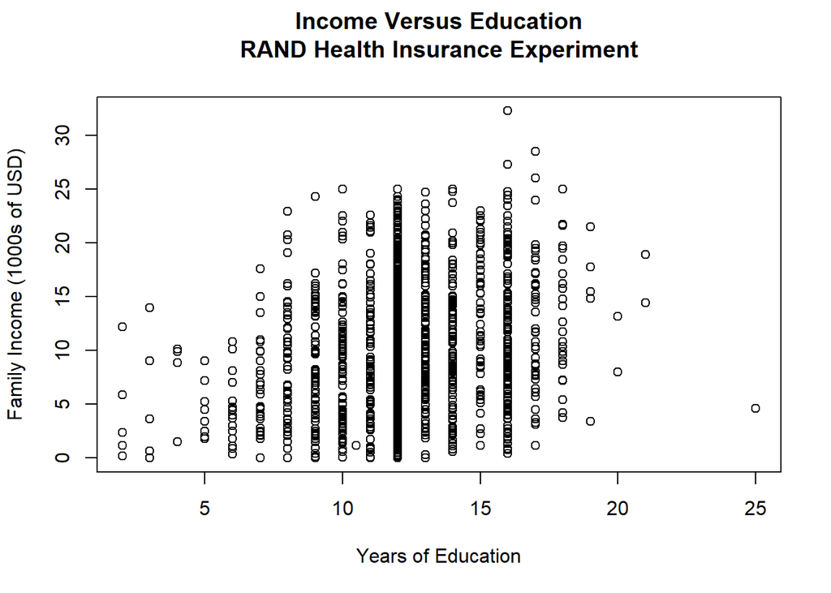

```r
plot(x = hiedata_short$education,
y = hiedata_short$income,
type = "p", # "p" = Points
xlab = "Years of Education",
ylab = "Family Income (1000s of USD)",
main = "Income Versus Education\nRAND Health Insurance Experiment\n",
)
```

- What does the fitted regression line tell us?

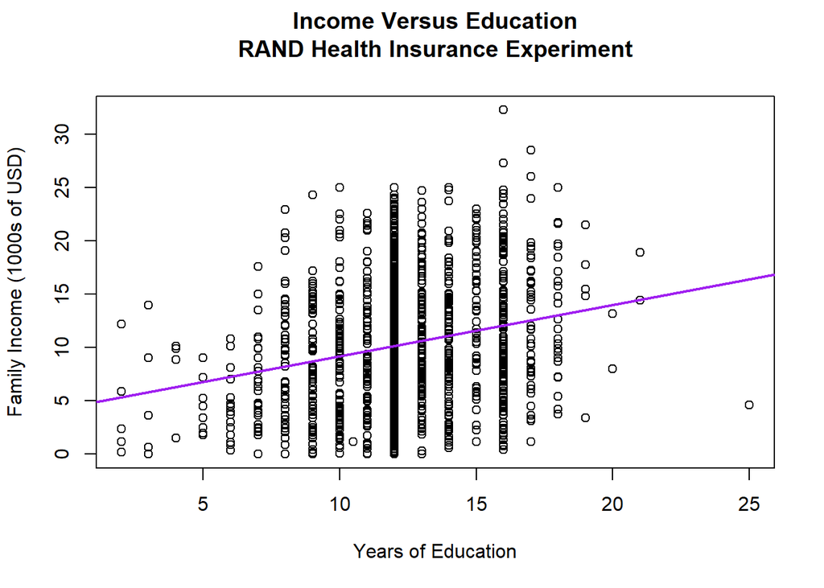

```r
plot(x = hiedata_short$education,
y = hiedata_short$income,
type = "p", # What type of plot? "p" = Points; Run: `?plot` for more details
col = "black", # Colour of the points
xlab = "Years of Education", # Add title for the x-axis
ylab = "Family Income (1000s of USD)", # Add title for the y-axis
main = "Income Versus Education\nRAND Health Insurance Experiment\n", # Add a plot title. "\n" = Insert line break
)

# Fit the basic regression
lm.educ <- lm(formula = income ~ education,
data = hiedata_short
)
# Add least squares fitted line to plot
abline(reg = lm.educ, # The saved regression model
lwd = 2, # Width of the regression line on the plot
col = "purple" # The color of the regression line on the plot
)
```

Answers: It is very difficult to tell whether the variables have a linear relationship from the scatter plot alone — especially as there is a lot of variation in family income amongst people with the same level of education. Still, the regression line indicates a positive association.

Accordingly, in this sample, people with more years of education are predicted to have, on average, higher levels of family income, thus the upward-sloping regression line. The slope coefficient for the regression line and the Pearson correlation coefficient have the same sign as the slope is from a simple linear regression model (see Page 39 of the MY452 Coursepack). Thus, the Pearson correlation coefficient for income and education is also positive

## At-Home Exercise 3

First, fit a simple linear regression model of income against education. Then, identify the estimates for the intercept/constant term (i.e., α or β0) and the regression coefficient for education (i.e., βeducation). - How do these estimated quantities relate to the fitted regression line in Exercise 2? Finally, identify and discuss the following quantities from the model output: • The 95% confidence interval for the estimate of βeducation • The t-test statistic for the estimate of βeducation and its associated p-value • The coefficient of determination (R2)

```r
# SOLUTIONS:
# Run a simple linear regression model
lm.educ <- lm(formula = income ~ education,
data = hiedata_short
)
summary(lm.educ) # Recall the detailed output
```

```
##
## Call:
## lm(formula = income ~ education, data = hiedata_short)
##
## Residuals:
##      Min       1Q   Median       3Q      Max
## -11.8074  -4.6933  -0.2931   4.0485  20.1926
##
## Coefficients:
##             Estimate Std. Error t value Pr(>|t|)
## (Intercept)  4.36710    0.68213   6.402 1.98e-10 ***
## education    0.48146    0.05432   8.863  < 2e-16 ***
## ---
## Signif. codes:  0 '***' 0.001 '**' 0.01 '*' 0.05 '.' 0.1 ' ' 1
##
## Residual standard error: 5.849 on 1697 degrees of freedom
##   (233 observations deleted due to missingness)
## Multiple R-squared:  0.04424,    Adjusted R-squared:  0.04368
## F-statistic: 78.56 on 1 and 1697 DF,  p-value: < 2.2e-16
```

ANSWER: • Estimated Constant Term: αˆ = 4.367 • Estimated Regression Coefficient for Education: βˆ = 0.481 The intercept (i.e., α, β0) indicates where the regression line of best fit in Exercise 2 intersects the y-axis. The coefficient for education (βeducation) is the slope of this line and it indicates the rate of change in income relative to education.

The interpretation of βˆ for education (0.481) is that, for one additional year of full-time education the expected family income will be higher by $481 (i.e. 0.481 × $1000).

The 95% confidence interval for the coefficient for education is (0.375; 0.588) or, rather, $375 to $588 — i.e., (0.375 × $1000; 0.588 × $1000). We are therefore 95% confident that the true model parameter lies between $375 and $588.

[Note “We are 95% confident. . .” means that, if we followed this procedure to construct the confidence interval over many repeated samples, 95% of these confidence intervals would contain the true population parameter.]

The t-statistic for the education regression coefficient is 8.863. The corresponding p-value is less than 0.001. The p-value of the t-test is very small, providing strong evidence against the null hypothesis that the population value of the coefficient for education is equal to 0 (i.e., H0 : βˆEducation = 0). Indeed, it is smaller than any conventionally used significance level in the social sciences (i.e., 0.05, 0.01, and 0.001). Therefore, we can reject the null hypothesis.

Accordingly, there is very strong statistical evidence that one’s level of education and family income are correlated in the population. This is also indicated by the fact that the confidence interval does not contain the value of 0.

Finally, an R2 of 0.044 indicates that 4.4% of the variation in the values of family income in the sample is explained by variation in the respondents’ levels of education. This proportion is not very large (as we can see in the scatterplot in Exercise 2).

Thus, level of education does not appear to be very useful for predicting an individual’s family income for these particular respondents — even though there is strong statistical evidence of an association between the two variables.